# ReneWind

### 2. GBM with undersampled data

```python
%%time

# defining model
Model = GradientBoostingClassifier(random_state=1)

# Parameter grid to pass in RandomSearchCV
param_grid =  { "n_estimators": np.arange(100,150,25), "learning_rate": [0.2, 0.05, 1], "subsample":[0.5,0.7], "max_features":[0.5,0.7] }

# Calling RandomizedSearchCV
randomized_cv = RandomizedSearchCV(
    estimator=Model,
    param_distributions=param_grid,
    n_iter=10,
    n_jobs=-1,
    scoring=scorer,
    cv=5,
    random_state=1,
)

# Fitting parameters in RandomizedSearchCV
randomized_cv.fit(X_train_un, y_train_un)

print(
    "Best parameters are {} with CV score={}:".format(
        randomized_cv.best_params_, randomized_cv.best_score_
    )
)
```

```
Best parameters are {'subsample': 0.5, 'n_estimators': 100, 'max_features': 0.7, 'learning_rate': 0.2} with CV score=0.9014140393910972:
CPU times: user 922 ms, sys: 37.8 ms, total: 959 ms
Wall time: 19.5 s
```

```python
# building model with best parameters
gbm_tuned_un = GradientBoostingClassifier(
    random_state=1, subsample=0.5, n_estimators=100, max_features=0.7, learning_rate=0.2
)

# Fit the model on training data
gbm_tuned_un.fit(X_train_un, y_train_un)
```

```
GradientBoostingClassifier(learning_rate=0.2, max_features=0.7, random_state=1,
                           subsample=0.5)
```

```python
# Calculating different metrics on train set
gbm_tuned_train_un = model_performance_classification_sklearn(
    gbm_tuned_un, X_train_un, y_train_un
)
print("Training performance:")
gbm_tuned_train_un
```

```
Training performance:
```

|  | Accuracy | Recall | Precision | F1 |
| --- | --- | --- | --- | --- |
| 0 | 0.985 | 0.975 | 0.995 | 0.985 |

```python
# Calculating different metrics on validation set
gbm_tuned_val_un = model_performance_classification_sklearn(gbm_tuned_un, X_val, y_val)
print("Validation performance:")
gbm_tuned_val_un
```

```
Validation performance:
```

|  | Accuracy | Recall | Precision | F1 |
| --- | --- | --- | --- | --- |
| 0 | 0.919 | 0.871 | 0.395 | 0.543 |

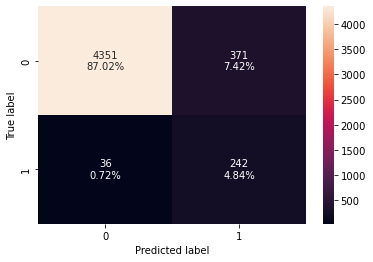

```python
# creating confusion matrix
confusion_matrix_sklearn(gbm_tuned_un, X_val, y_val)
```

- Recall is okay but precision is very low.

### 3. AdaBoost oversampled data

```python
%%time

# defining model
Model = AdaBoostClassifier(random_state=1)

# Parameter grid to pass in RandomSearchCV
param_grid = { "n_estimators": [100, 150, 200], "learning_rate": [0.2, 0.05], "base_estimator": [DecisionTreeClassifier(max_depth=1, random_state=1), DecisionTreeClassifier(max_depth=2, random_state=1), DecisionTreeClassifier(max_depth=3, random_state=1), ] }


# Calling RandomizedSearchCV
randomized_cv = RandomizedSearchCV(
    estimator=Model,
    param_distributions=param_grid,
    n_iter=10,
    n_jobs=-1,
    scoring=scorer,
    cv=5,
    random_state=1,
)

# Fitting parameters in RandomizedSearchCV
randomized_cv.fit(X_train_over, y_train_over)

print(
    "Best parameters are {} with CV score={}:".format(
        randomized_cv.best_params_, randomized_cv.best_score_
    )
)
```

```
Best parameters are {'n_estimators': 200, 'learning_rate': 0.2, 'base_estimator': DecisionTreeClassifier(max_depth=3, random_state=1)} with CV score=0.9715559462639259:
CPU times: user 1min 49s, sys: 1.97 s, total: 1min 51s
Wall time: 20min 12s
```

```python
# building model with best parameters
ada_tuned_over = AdaBoostClassifier(
    n_estimators=200,
    learning_rate=0.2,
    base_estimator=DecisionTreeClassifier(max_depth=3, random_state=1),
)

# Fit the model on training data
ada_tuned_over.fit(X_train_over, y_train_over)
```

```
AdaBoostClassifier(base_estimator=DecisionTreeClassifier(max_depth=3,
                                                         random_state=1),
                   learning_rate=0.2, n_estimators=200)
```

```python
# Calculating different metrics on train set
ada_tuned_train_over = model_performance_classification_sklearn(
    ada_tuned_over, X_train_over, y_train_over
)
print("Training performance:")
ada_tuned_train_over
```

```
Training performance:
```

|  | Accuracy | Recall | Precision | F1 |
| --- | --- | --- | --- | --- |
| 0 | 0.992 | 0.988 | 0.995 | 0.992 |

```python
# Calculating different metrics on validation set
ada_tuned_val_over = model_performance_classification_sklearn(
    ada_tuned_over, X_val, y_val
)
print("Validation performance:")
ada_tuned_val_over
```

```
Validation performance:
```

|  | Accuracy | Recall | Precision | F1 |
| --- | --- | --- | --- | --- |
| 0 | 0.979 | 0.849 | 0.789 | 0.818 |

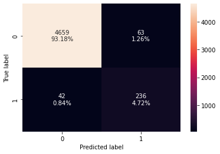

```python
# creating confusion matrix
confusion_matrix_sklearn(ada_tuned_over, X_val, y_val)
```

### 4. AdaBoost undersampled data

```python
%%time

# defining model
Model = AdaBoostClassifier(random_state=1)

# Parameter grid to pass in RandomSearchCV
param_grid = { "n_estimators": [100, 150, 200], "learning_rate": [0.2, 0.05], "base_estimator": [DecisionTreeClassifier(max_depth=1, random_state=1), DecisionTreeClassifier(max_depth=2, random_state=1), DecisionTreeClassifier(max_depth=3, random_state=1), ] }


# Calling RandomizedSearchCV
randomized_cv = RandomizedSearchCV(
    estimator=Model,
    param_distributions=param_grid,
    n_iter=10,
    n_jobs=-1,
    scoring=scorer,
    cv=5,
    random_state=1,
)

# Fitting parameters in RandomizedSearchCV
randomized_cv.fit(X_train_un, y_train_un)

print(
    "Best parameters are {} with CV score={}:".format(
        randomized_cv.best_params_, randomized_cv.best_score_
    )
)
```

```
Best parameters are {'n_estimators': 100, 'learning_rate': 0.05, 'base_estimator': DecisionTreeClassifier(max_depth=3, random_state=1)} with CV score=0.8858091046822019:
CPU times: user 2.48 s, sys: 62.4 ms, total: 2.54 s
Wall time: 53.6 s
```

```python
# building model with best parameters
ada_tuned_un = AdaBoostClassifier(
    n_estimators=100,
    learning_rate=0.05,
    base_estimator=DecisionTreeClassifier(max_depth=3, random_state=1),
)

# Fit the model on training data
ada_tuned_un.fit(X_train_un, y_train_un)
```

```
AdaBoostClassifier(base_estimator=DecisionTreeClassifier(max_depth=3,
                                                         random_state=1),
                   learning_rate=0.05, n_estimators=100)
```

```python
# Calculating different metrics on train set
ada_tuned_train_un = model_performance_classification_sklearn(
    ada_tuned_un, X_train_un, y_train_un
)
print("Training performance:")
ada_tuned_train_un
```

```
Training performance:
```

|  | Accuracy | Recall | Precision | F1 |
| --- | --- | --- | --- | --- |
| 0 | 0.969 | 0.944 | 0.994 | 0.968 |

```python
# Calculating different metrics on validation set
ada_tuned_val_un = model_performance_classification_sklearn(ada_tuned_un, X_val, y_val)
print("Validation performance:")
ada_tuned_val_un
```

```
Validation performance:
```

|  | Accuracy | Recall | Precision | F1 |
| --- | --- | --- | --- | --- |
| 0 | 0.928 | 0.888 | 0.430 | 0.579 |

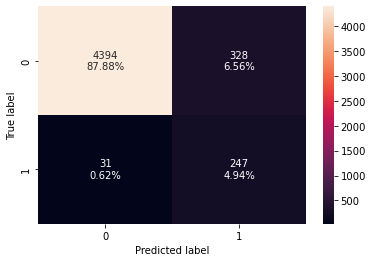

```python
# creating confusion matrix
confusion_matrix_sklearn(ada_tuned_un, X_val, y_val)
```

- The recall score is good even the precision score is low.
- Since the cost of replacing a generator is a lot higher than repair and inspection, we would like false negative to be very low.
- This model has the lowest false negative and has okay false positive.
- This model could provide the best cost saving solution on operation and maintenance.

## Model performance comparison and choosing the final model

```python
# training performance comparison

models_train_comp_df = pd.concat(
    [
        gbm_tuned_train_over.T,
        gbm_tuned_train_un.T,
        ada_tuned_train_over.T,
        ada_tuned_train_un.T,
    ],
    axis=1,
)
models_train_comp_df.columns = [
    "GBM Oversample Tuned",
    "GBM Undersample Tuned",
    "AdaBoost Oversample Tuned",
    "AdaBoost Undersample Tuned",
]
print("Training performance comparison:")
models_train_comp_df
```

```
Training performance comparison:
```

|  | GBM Oversample Tuned | GBM Undersample Tuned | AdaBoost Oversample Tuned | AdaBoost Undersample Tuned |
| --- | --- | --- | --- | --- |
| Accuracy | 0.993 | 0.985 | 0.992 | 0.969 |
| Recall | 0.992 | 0.975 | 0.988 | 0.944 |
| Precision | 0.994 | 0.995 | 0.995 | 0.994 |
| F1 | 0.993 | 0.985 | 0.992 | 0.968 |

```python
# Validation performance comparison

models_val_comp_df = pd.concat(
    [
        gbm_tuned_val_over.T,
        gbm_tuned_val_un.T,
        ada_tuned_val_over.T,
        ada_tuned_val_un.T,
    ],
    axis=1,
)
models_val_comp_df.columns = [
    "GBM Oversample Tuned",
    "GBM Undersample Tuned",
    "AdaBoost Oversample Tuned",
    "AdaBoost Undersample Tuned",
]
print("Validation performance comparison:")
models_val_comp_df
```

```
Validation performance comparison:
```

|  | GBM Oversample Tuned | GBM Undersample Tuned | AdaBoost Oversample Tuned | AdaBoost Undersample Tuned |
| --- | --- | --- | --- | --- |
| Accuracy | 0.969 | 0.919 | 0.979 | 0.928 |
| Recall | 0.856 | 0.871 | 0.849 | 0.888 |
| Precision | 0.678 | 0.395 | 0.789 | 0.430 |
| F1 | 0.757 | 0.543 | 0.818 | 0.579 |

- AdaBoost Undersample Tuned model has best recall score. It could provide the best cost saving solution on operation and maintenance.
- We will check this model performance on the test set.

### Test set final performance

### AdaBoost Undersample Tuned

```python
# Calculating different metrics on the test set
ada_tuned_test_un = model_performance_classification_sklearn(
    ada_tuned_un, X_test, y_test
)
print("Test performance:")
ada_tuned_test_un
```

```
Test performance:
```

|  | Accuracy | Recall | Precision | F1 |
| --- | --- | --- | --- | --- |
| 0 | 0.934 | 0.855 | 0.454 | 0.593 |

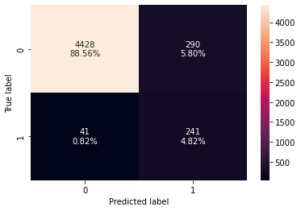

```python
# creating confusion matrix
confusion_matrix_sklearn(ada_tuned_un, X_test, y_test)
```

- The model performed well with the test dataset.
- The recall score is 0.855 with a low false negative number, 41 observations.
- This model is good to predict which wine turbine will be failed soon.
- We will check feature importance next

### GBM Undersample Tuned

```python
# Calculating different metrics on the test set
gbm_tuned_test_un = model_performance_classification_sklearn(
    gbm_tuned_un, X_test, y_test
)
print("Test performance:")
gbm_tuned_test_un
```

```
Test performance:
```

|  | Accuracy | Recall | Precision | F1 |
| --- | --- | --- | --- | --- |
| 0 | 0.922 | 0.865 | 0.409 | 0.555 |

### Feature importance of Tuned AdaBoost

```python
X_train  # check if X_train is in a dataframe or numpy arrays
```

```
array([[-3.17491123e-01, -2.77659489e+00,  9.00126721e+00, ...,
        -4.39391147e+00,  3.18860423e+00, -4.24493235e+00],
       [ 5.25019092e+00,  4.51415851e+00,  1.07323162e+00, ...,
         4.37498026e+00, -1.18025995e+00, -2.34825891e+00],
       [-2.07340418e+00, -6.21925320e-01, -1.42606198e+00, ...,
        -3.38946469e+00,  6.22733900e-03, -1.27436530e+00],
       ...,
       [-3.26640663e+00, -1.57249116e+00,  2.40740906e+00, ...,
        -1.93250007e+00,  1.21687611e+00, -2.69722781e+00],
       [-4.39282327e+00,  9.50964655e-01,  2.84143332e-01, ...,
         3.45700418e+00,  1.55330997e+00, -1.70519785e+00],
       [-5.11891937e-01,  2.46313510e+00, -3.03179527e+00, ...,
         7.32421395e+00,  3.26489060e-02, -5.87137812e-01]])
```

```python
df = pd.DataFrame(X_train)  # to create a dataframe from arrays
```

```python
df.head()  # to check how the dataframe look like
```

|  | 0 | 1 | 2 | 3 | 4 | 5 | 6 | 7 | 8 | 9 | 10 | 11 | 12 | 13 | 14 | 15 | 16 | 17 | 18 | 19 | 20 | 21 | 22 | 23 | 24 | 25 | 26 | 27 | 28 | … |
| --- | --- | --- | --- | --- | --- | --- | --- | --- | --- | --- | --- | --- | --- | --- | --- | --- | --- | --- | --- | --- | --- | --- | --- | --- | --- | --- | --- | --- | --- | --- |
| 0 | -0.317 | -2.777 | 9.001 | -0.053 | -1.899 | -3.715 | -3.017 | -0.753 | -0.519 | 3.455 | -6.192 | 1.978 | 4.294 | -0.068 | -4.655 | -6.406 | -2.224 | 1.212 | 4.495 | 2.947 | -8.715 | 0.986 | -4.498 | 1.116 | 1.963 | 1.974 | 2.343 | -2.061 | -4.546 | … |
| 1 | 5.250 | 4.514 | 1.073 | 1.947 | -1.517 | 1.004 | 0.500 | -5.055 | 3.736 | -1.426 | 1.756 | -2.086 | 1.296 | -2.717 | -1.771 | -7.661 | -1.332 | -1.202 | 2.795 | -3.098 | -6.122 | 2.531 | -1.773 | -0.556 | 0.159 | 4.070 | 1.496 | -0.197 | -0.323 | … |
| 2 | -2.073 | -0.622 | -1.426 | -0.494 | 0.957 | -3.341 | -0.811 | 4.600 | -2.031 | -1.162 | -3.335 | 7.733 | 4.182 | 0.301 | -5.524 | -0.088 | 1.694 | 3.055 | 0.639 | 0.594 | -4.772 | 4.228 | 9.382 | 5.447 | -2.474 | 0.749 | -4.680 | -1.139 | -2.591 | … |
| 3 | -3.322 | -1.914 | 2.288 | -1.230 | -0.353 | -0.187 | -0.739 | -1.530 | -1.741 | 2.463 | -1.768 | 2.507 | 0.148 | -0.521 | -1.097 | -2.114 | -0.922 | 1.895 | 2.495 | 1.003 | -0.699 | -0.219 | -2.413 | 0.737 | 0.234 | -1.090 | 1.421 | 0.585 | -1.185 | … |
| 4 | -1.916 | 4.899 | 6.290 | 1.694 | 2.435 | -1.941 | 0.380 | 1.292 | -3.857 | 0.972 | 0.427 | 3.419 | 0.178 | -3.113 | -0.251 | 2.694 | -3.216 | -3.238 | 4.030 | -6.597 | -2.200 | -3.005 | -2.832 | 5.909 | -3.235 | 9.155 | -4.344 | -2.859 | 2.004 | … |

```python
# to rename columns
df.rename(
    columns={
        0: "V1",
        1: "V2",
        2: "V3",
        3: "V4",
        4: "V5",
        5: "V6",
        6: "V7",
        7: "V8",
        8: "V9",
        9: "V10",
        10: "V11",
        11: "V12",
        12: "V13",
        13: "V14",
        14: "V15",
        15: "V16",
        16: "V17",
        17: "V18",
        18: "V19",
        19: "V20",
        20: "V21",
        21: "V22",
        23: "V23",
        24: "V24",
        25: "V25",
        26: "V26",
        26: "V27",
        27: "V28",
        28: "V29",
        29: "V30",
        30: "V31",
        31: "V32",
        32: "V33",
        33: "V34",
        34: "V35",
        35: "V36",
        36: "V37",
        37: "V38",
        38: "V39",
        39: "V40",
    },
    inplace=True,
)
```

```python
# to check if column names have been changed.
X_train = df
X_train.head()
```

|  | V1 | V2 | V3 | V4 | V5 | V6 | V7 | V8 | V9 | V10 | V11 | V12 | V13 | V14 | V15 | V16 | V17 | V18 | V19 | V20 | V21 | V22 | 22 | V23 | V24 | V25 | V27 | V28 | V29 | … |
| --- | --- | --- | --- | --- | --- | --- | --- | --- | --- | --- | --- | --- | --- | --- | --- | --- | --- | --- | --- | --- | --- | --- | --- | --- | --- | --- | --- | --- | --- | --- |
| 0 | -0.317 | -2.777 | 9.001 | -0.053 | -1.899 | -3.715 | -3.017 | -0.753 | -0.519 | 3.455 | -6.192 | 1.978 | 4.294 | -0.068 | -4.655 | -6.406 | -2.224 | 1.212 | 4.495 | 2.947 | -8.715 | 0.986 | -4.498 | 1.116 | 1.963 | 1.974 | 2.343 | -2.061 | -4.546 | … |
| 1 | 5.250 | 4.514 | 1.073 | 1.947 | -1.517 | 1.004 | 0.500 | -5.055 | 3.736 | -1.426 | 1.756 | -2.086 | 1.296 | -2.717 | -1.771 | -7.661 | -1.332 | -1.202 | 2.795 | -3.098 | -6.122 | 2.531 | -1.773 | -0.556 | 0.159 | 4.070 | 1.496 | -0.197 | -0.323 | … |
| 2 | -2.073 | -0.622 | -1.426 | -0.494 | 0.957 | -3.341 | -0.811 | 4.600 | -2.031 | -1.162 | -3.335 | 7.733 | 4.182 | 0.301 | -5.524 | -0.088 | 1.694 | 3.055 | 0.639 | 0.594 | -4.772 | 4.228 | 9.382 | 5.447 | -2.474 | 0.749 | -4.680 | -1.139 | -2.591 | … |
| 3 | -3.322 | -1.914 | 2.288 | -1.230 | -0.353 | -0.187 | -0.739 | -1.530 | -1.741 | 2.463 | -1.768 | 2.507 | 0.148 | -0.521 | -1.097 | -2.114 | -0.922 | 1.895 | 2.495 | 1.003 | -0.699 | -0.219 | -2.413 | 0.737 | 0.234 | -1.090 | 1.421 | 0.585 | -1.185 | … |
| 4 | -1.916 | 4.899 | 6.290 | 1.694 | 2.435 | -1.941 | 0.380 | 1.292 | -3.857 | 0.972 | 0.427 | 3.419 | 0.178 | -3.113 | -0.251 | 2.694 | -3.216 | -3.238 | 4.030 | -6.597 | -2.200 | -3.005 | -2.832 | 5.909 | -3.235 | 9.155 | -4.344 | -2.859 | 2.004 | … |

```python
feature_names = X_train.columns
```

```python
importances = ada_tuned_un.feature_importances_
```

```python
indices = np.argsort(importances)
```

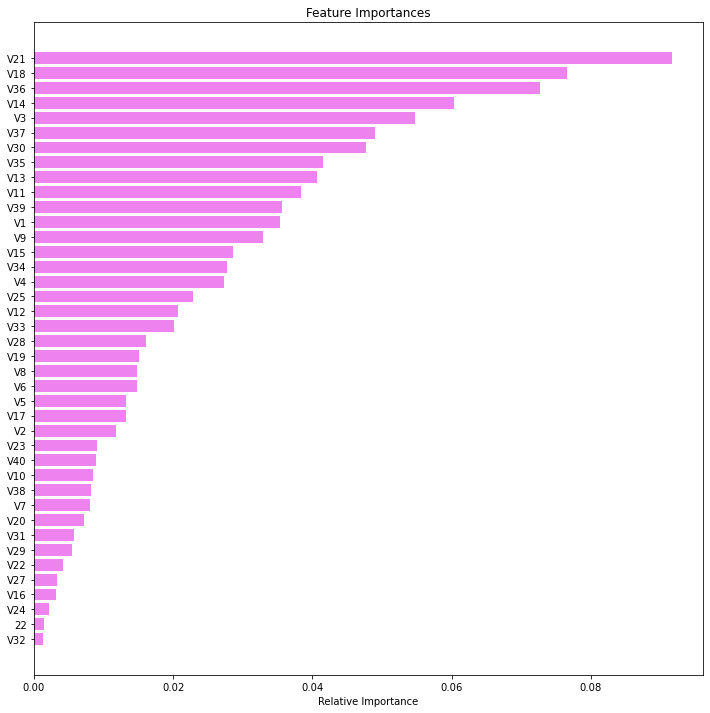

```python
plt.figure(figsize=(12, 12))
plt.title("Feature Importances")
plt.barh(range(len(indices)), importances[indices], color="violet", align="center")
plt.yticks(range(len(indices)), [feature_names[i] for i in indices])
plt.xlabel("Relative Importance")
plt.show()
```

- The top 5 features with the highest relative importance are V21 (0.1), V18 (0.08), V36 (0.075), V14 (0.06), and V3 (0.055).
- From the chart, there are a few groups (V35, V13, V11) or pairs (V37, V30) that have similar relative importance. They may be some relationship between those features.